## Practical Machine Learning Project

# Introduction

Using devices such as Jawbone Up, Nike FuelBand, and Fitbit it is now possible to collect a large amount of data about personal activity relatively inexpensively. These type of devices are part of the quantified self movement â a group of enthusiasts who take measurements about themselves regularly to improve their health, to find patterns in their behavior, or because they are tech geeks. One thing that people regularly do is quantify how much of a particular activity they do, but they rarely quantify how well they do it.

In this project, we will use data from accelerometers on the belt, forearm, arm, and dumbell of 6 participants to predict the manner in which they did the exercise. We will start by importing the necessary libraries.

```r
library(caret)
```

```r
library(rpart)
library(rpart.plot)
library(randomForest)
library(corrplot)
```

## Loading the Data

```r
trainData <- read.csv(url("https://d396qusza40orc.cloudfront.net/predmachlearn/pml-training.csv"), header =TRUE)
dim(trainData)
```

```
## [1] 19622   160
```

```r
testData <- read.csv(url("https://d396qusza40orc.cloudfront.net/predmachlearn/pml-testing.csv"),header=TRUE)
dim(testData)
```

```
## [1]  20 160
```

## Let’s look at the structure of the dataset

```r
str(trainData)
```

```
## 'data.frame':    19622 obs. of  160 variables:
##  $ X                       : int  1 2 3 4 5 6 7 8 9 10 ...
##  $ user_name               : Factor w/ 6 levels "adelmo","carlitos",..: 2 2 2 2 2 2 2 2 2 2 ...
##  $ raw_timestamp_part_1    : int  1323084231 1323084231 1323084231 1323084232 1323084232 1323084232 1323084232 1323084232 1323084232 1323084232 ...
##  $ raw_timestamp_part_2    : int  788290 808298 820366 120339 196328 304277 368296 440390 484323 484434 ...
##  $ cvtd_timestamp          : Factor w/ 20 levels "02/12/2011 13:32",..: 9 9 9 9 9 9 9 9 9 9 ...
##  $ new_window              : Factor w/ 2 levels "no","yes": 1 1 1 1 1 1 1 1 1 1 ...
##  $ num_window              : int  11 11 11 12 12 12 12 12 12 12 ...
##  $ roll_belt               : num  1.41 1.41 1.42 1.48 1.48 1.45 1.42 1.42 1.43 1.45 ...
##  $ pitch_belt              : num  8.07 8.07 8.07 8.05 8.07 8.06 8.09 8.13 8.16 8.17 ...
##  $ yaw_belt                : num  -94.4 -94.4 -94.4 -94.4 -94.4 -94.4 -94.4 -94.4 -94.4 -94.4 ...
##  $ total_accel_belt        : int  3 3 3 3 3 3 3 3 3 3 ...
##  $ kurtosis_roll_belt      : Factor w/ 397 levels "","-0.016850",..: 1 1 1 1 1 1 1 1 1 1 ...
##  $ kurtosis_picth_belt     : Factor w/ 317 levels "","-0.021887",..: 1 1 1 1 1 1 1 1 1 1 ...
##  $ kurtosis_yaw_belt       : Factor w/ 2 levels "","#DIV/0!": 1 1 1 1 1 1 1 1 1 1 ...
```

[output cut: 86 more lines]

The training set consists of 19622 observations and 160 varibales. But as we can see many of those columns have NA values or blank values. So we will remove them as they do not contain any information and including them will only increase the complexity of the model. The first 7 columns give information about the user and timestamps. We will remove them too.

```r
indColtoRem <- which(colSums(is.na(trainData) | trainData == "")>0.9*dim(trainData)[1])
trainDataClean <- trainData[,-indColtoRem]
trainDataClean <- trainDataClean[,-c(1:7)]
dim(trainDataClean)
```

```
## [1] 19622    53
```

Now we will apply same transformation to the test data

```r
indColToRemove <- which(colSums(is.na(testData) |testData=="")>0.9*dim(testData)[1])
testDataClean <- testData[,-indColToRemove]
testDataClean <- testDataClean[,-c(1:7)]
#testDataClean <- testDataClean[,-1]
dim(testDataClean)
```

```
## [1] 20 53
```

for cross validation we will split the training data into two parts one for training(75%) and other for validation(25%)

```r
set.seed(12345)
inTrain <- createDataPartition(trainData$classe, p=0.75, list=FALSE)
train1 <- trainDataClean[inTrain,]
validnData <- trainDataClean[-inTrain,]
dim(train1)
```

```
## [1] 14718    53
```

```r
dim(validnData)
```

```
## [1] 4904   53
```

## Training and Cross Validation

Here we will be using Random Forest model because it automaticallly identifies the important features that gives best performance and is robust to outliers. We will using 5-fold cross validation to limit effects of overfitting

```r
rfControl = trainControl(method = "cv", number = 5)
rfModel = train(classe~., data = train1, method="rf", trControl = rfControl, verbose = FALSE)
rfModel
```

```
## Random Forest
##
## 14718 samples
##    52 predictor
##     5 classes: 'A', 'B', 'C', 'D', 'E'
##
## No pre-processing
## Resampling: Cross-Validated (5 fold)
## Summary of sample sizes: 11775, 11773, 11774, 11775, 11775
## Resampling results across tuning parameters:
##
##   mtry  Accuracy   Kappa
##    2    0.9907600  0.9883109
##   27    0.9921866  0.9901157
##   52    0.9895370  0.9867641
##
## Accuracy was used to select the optimal model using the largest value.
## The final value used for the model was mtry = 27.
```

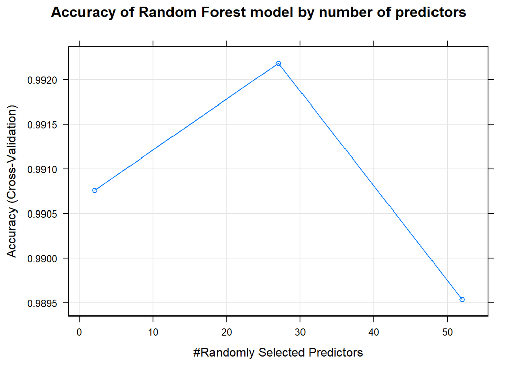

```r
plot(rfModel, main="Accuracy of Random Forest model by number of predictors")
```

## Predicting on validation data

```r
pred <- predict(rfModel, newdata = validnData)
length(pred)
```

```
## [1] 4904
```

```r
rfConfMt <- confusionMatrix(validnData$classe, pred)

rfConfMt
```

```
## Confusion Matrix and Statistics
##
##           Reference
## Prediction    A    B    C    D    E
##          A 1394    1    0    0    0
##          B    6  939    4    0    0
##          C    0    3  848    4    0
##          D    0    0    8  796    0
##          E    0    0    2    6  893
##
## Overall Statistics
##
##                Accuracy : 0.9931
##                  95% CI : (0.9903, 0.9952)
##     No Information Rate : 0.2855
##     P-Value [Acc > NIR] : < 2.2e-16
##
##                   Kappa : 0.9912
##  Mcnemar's Test P-Value : NA
##
## Statistics by Class:
##
##                      Class: A Class: B Class: C Class: D Class: E
## Sensitivity            0.9957   0.9958   0.9838   0.9876   1.0000
## Specificity            0.9997   0.9975   0.9983   0.9980   0.9980
## Pos Pred Value         0.9993   0.9895   0.9918   0.9900   0.9911
## Neg Pred Value         0.9983   0.9990   0.9965   0.9976   1.0000
## Prevalence             0.2855   0.1923   0.1758   0.1644   0.1821
## Detection Rate         0.2843   0.1915   0.1729   0.1623   0.1821
## Detection Prevalence   0.2845   0.1935   0.1743   0.1639   0.1837
## Balanced Accuracy      0.9977   0.9966   0.9910   0.9928   0.9990
```

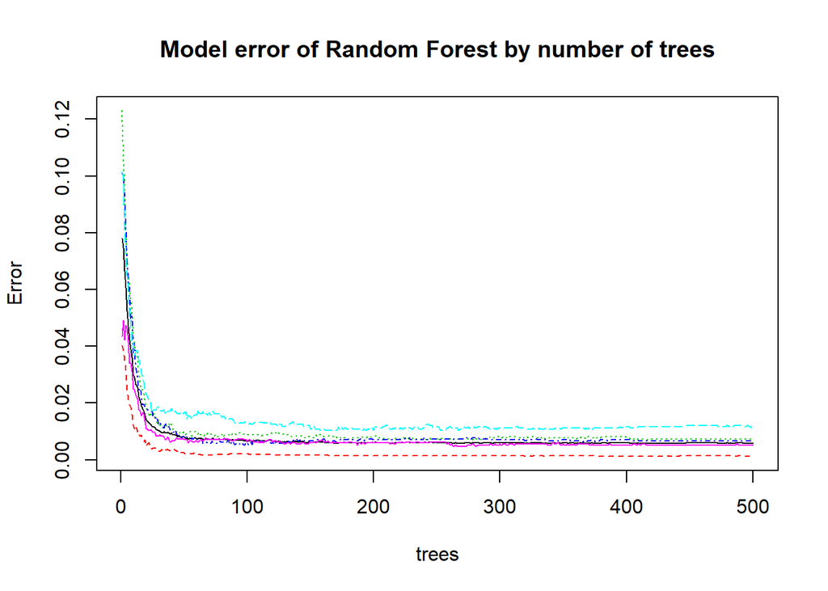

```r
plot(rfModel$finalModel, main = "Model error of Random Forest by number of trees")
```

```r
finalPred <- predict(rfModel, newdata = testDataClean)
finalPred
```

```
##  [1] B A B A A E D B A A B C B A E E A B B B
## Levels: A B C D E
```